# Analysis of Beer Reviews(9/28/2001 - 1/27/2014)

Lance J. Fernando, Rachel Kim, Ien Whang and Aren Dakessian

2/16/2017

This in-class case study was conducted in BSDS100: Introduction to Data Science at the University of San Francisco

### 1)

There are **89** different beers in the study.

```r
load("/Users/lancefernando/Desktop/USFSpring2017/BSDS100/CaseStudy/Beers/beer.data.Rdata")

#Converting Name into a factor to compare levels
beer.data$Name <- as.factor(beer.data$Name)

#Computing the number of different beers based on Name
length(unique(beer.data$Name))
```

```
## [1] 89
```

### 2)

First and last date of reviews. **“2001-09-28” — “2014-01-27”**

```r
#Computing the max and minimum dates
max(beer.data$Date)
```

```
## [1] "2014-01-27"
```

```r
min(beer.data$Date)
```

```
## [1] "2001-09-28"
```

### 3)

There are **86** different beers from California

```r
#Creating subset for beers from CA
calBeers <- beer.data[beer.data$Origin == "California", ]

#Calculating length of unique levels in CA beers by name
length(unique(as.factor(calBeers$Name)))
```

```
## [1] 86
```

### 4)

Highest rated beer **5**, lowest rated beer **1**

```r
#Computing the range of beer ratings
cat("Highest rated beer: ", max(beer.data$Rating, na.rm = TRUE))
```

```
## Highest rated beer:  5
```

```r
cat("Lowest rated beer: ", min(beer.data$Rating, na.rm = TRUE))
```

```
## Lowest rated beer:  1
```

### 5)

#### Alcohol content

a)Highest alcohol type: *American Strong Ale*

```r
beer.data$Style[which.max(beer.data$ABV)]
```

[output not shown]

b)Highest alcohol beer: *Samuel Adams Utopias*

```r
beer.data$Name[which.max(beer.data$ABV)]
```

[output not shown]

c)Lowest alcohol type: *Fruit / Vegetable Beer*

```r
beer.data$Style[which.min(beer.data$ABV)]
```

[output not shown]

d)Lowest alcohol beer: *Wisconsin Belgian Red*

```r
beer.data$Name[which.min(beer.data$ABV)]
```

[output not shown]

### 6)

Based on the findings, higher ABV does not necessarily equate higher ratings as their calculated mean differences in ratings are just .01.

```r
#Making subsets of ABV less than and greater than 5%
lowerABV <- beer.data[beer.data$ABV < 5,]
higherABV <- beer.data[beer.data$ABV > 5,]


cat("Mean Rating of lower ABV beers: ",mean(lowerABV$Rating, na.rm = TRUE))
```

```
## Mean Rating of lower ABV beers:  4.329925
```

```r
cat("Mean Rating of higher ABV beers: ",mean(higherABV$Rating, na.rm = TRUE))
```

```
## Mean Rating of higher ABV beers:  4.343558
```

### 8)

The ABV of “Imperial” beers has a much higher mean than those that are not “Imperial” and they are **9.34** and **8.074** respectively. In addition, the standard deviation of “Imperial” beers is smaller and therefore the ABV is much more centered around its mean while those that are not “Imperial” have a greater variance.

```r
#Creating a logical vector which is TRUE if the style contains "Imperial" and FALSE otherwise
is_imperial <- grepl("Imperial", beer.data$Style)

#Statistical comparison of beers that are and aren't "Imperial"
cat("Mean of Imperial beers:", mean(beer.data$ABV[is_imperial], na.rm = TRUE))
```

```
## Mean of Imperial beers: 9.340414
```

```r
cat("Mean of non-Imperial beers:", mean(beer.data$ABV[!is_imperial], na.rm = TRUE))
```

```
## Mean of non-Imperial beers: 8.074157
```

```r
cat("SD of Imperial beers:",sd(beer.data$ABV[is_imperial], na.rm = TRUE))
```

```
## SD of Imperial beers: 1.14857
```

```r
cat("SD of non-Imperial beers:",sd(beer.data$ABV[!is_imperial], na.rm = TRUE))
```

```
## SD of non-Imperial beers: 2.606791
```

### 9)

#### Method1:

Creating five collections of worst to best beers based on the average rating of the specific **Style** of beer. Collections are then produce based on the number of pos/neg standard deviations from the mean.

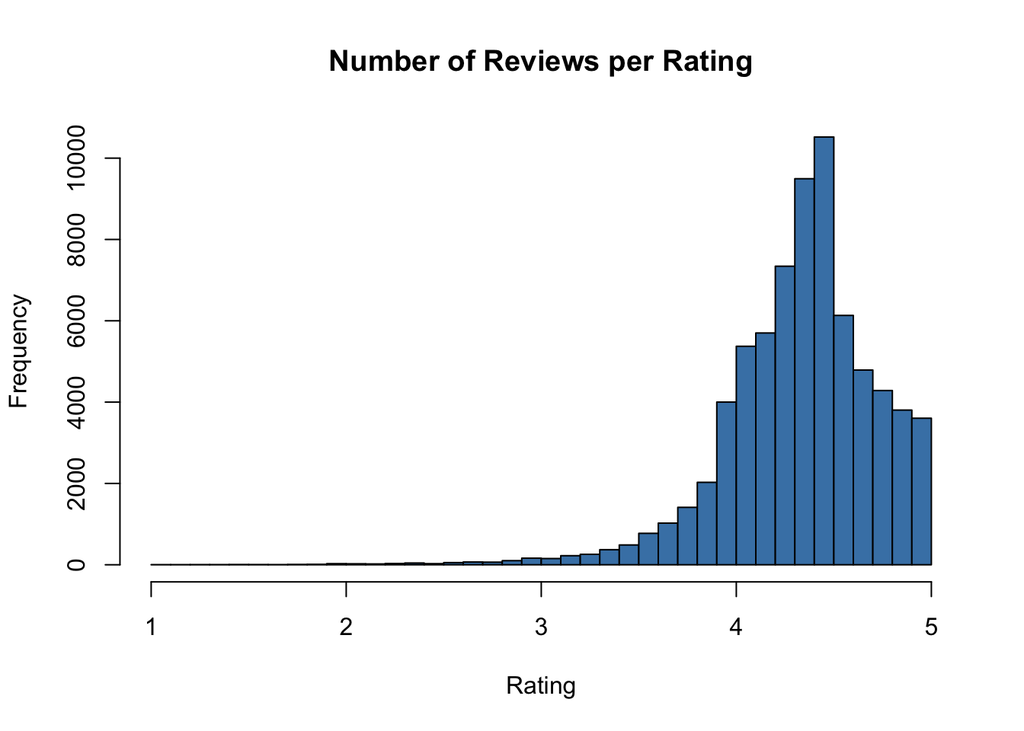

```r
hist(beer.data$Rating,
     main = "Number of Reviews per Rating",
     xlab = "Rating",
     col = "steelblue",
     n = 50)
```

##### Code solution below

```r
#Grabbing all the styles as a vector of strings
styles <- levels(as.factor(beer.data$Style))

#creating empty vector which will eventually hold the average of each style
style_avg <- rep(0, length(styles))

for(i in 1:length(styles)){

  #Computing avg based on style
  style_avg[i] <- mean(beer.data$Rating[beer.data$Style == styles[i]],
                       na.rm = TRUE)
}

#Naming each avg value their respective style name
names(style_avg) <- styles
style_avg
```

```
##           American Amber / Red Ale                American Barleywine
##                           4.356663                           4.397016
##                 American Black Ale     American Double / Imperial IPA
##                           4.242315                           4.459887
## American Double / Imperial Pilsner   American Double / Imperial Stout
##                           4.356345                           4.315254
##                       American IPA            American Pale Ale (APA)
##                           4.269955                           4.212991
##                    American Porter                American Strong Ale
##                           4.296124                           4.281004
##                  American Wild Ale                      Baltic Porter
##                           4.393851                           4.370135
##            Belgian Strong Dark Ale            Belgian Strong Pale Ale
##                           4.299267                           4.307282
##                         Doppelbock                             Dubbel
##                           4.331010                           4.471078
##                       Dunkelweizen                            Eisbock
##                           4.250776                           4.334467
##                 Flanders Oud Bruin                   Flanders Red Ale
##                           4.174168                           4.275342
##             Fruit / Vegetable Beer                             Gueuze
##                           4.329925                           4.350341
##                         Hefeweizen                     Lambic - Fruit
##                           4.416570                           4.326118
##                 Lambic - Unblended                            Old Ale
##                           4.210866                           4.530000
##                   Quadrupel (Quad)             Russian Imperial Stout
##                           4.469136                           4.301662
##             Scotch Ale / Wee Heavy                             Tripel
##                           4.203305                           4.284431
##                         Weizenbock
##                           4.281693
```

```r
#Computing total mean and sd
tot_avg <- mean(style_avg)
tot_sd <- sd(style_avg)

#Creating empty collection vectors
collection1 <- NA
collection2 <- NA
collection3 <- NA
collection4 <- NA
collection5 <- NA


#Adding each style to collection based on avg rating value and number of SDs from mean
for(i in 1:length(style_avg)){
  if(style_avg[i] < tot_avg){

    if(style_avg[i] < (tot_avg - tot_sd))
      collection1 <- c(collection1, names(style_avg)[i])

    else
      collection2 <- c(collection2, names(style_avg)[i])
  }

  else{
    if(style_avg[i] > tot_avg + (2 * tot_sd))
      collection5 <- c(collection5, names(style_avg)[i])

    else if(style_avg[i] > tot_avg + tot_sd)
      collection4 <- c(collection4, names(style_avg)[i])

    else
      collection3 <- c(collection3, names(style_avg)[i])
  }
}

#Removing initial NA value used to create the collections
collection1 <- collection1[-1]
collection2 <- collection2[-1]
collection3 <- collection3[-1]
collection4 <- collection4[-1]
collection5 <- collection5[-1]

#Printing collections
cat("Collection1: ",collection1, sep = "; ")
```

```
## Collection1: ; American Pale Ale (APA); Flanders Oud Bruin; Lambic - Unblended; Scotch Ale / Wee Heavy
```

```r
cat("Collection2: ",collection2, sep = "; ")
```

```
## Collection2: ; American Black Ale; American Double / Imperial Stout; American IPA; American Porter; American Strong Ale; Belgian Strong Dark Ale; Belgian Strong Pale Ale; Dunkelweizen; Flanders Red Ale; Russian Imperial Stout; Tripel; Weizenbock
```

```r
cat("Collection3: ",collection3, sep = "; ")
```

```
## Collection3: ; American Amber / Red Ale; American Barleywine; American Double / Imperial Pilsner; American Wild Ale; Baltic Porter; Doppelbock; Eisbock; Fruit / Vegetable Beer; Gueuze; Lambic - Fruit
```

```r
cat("Collection4: ",collection4, sep = "; ")
```

```
## Collection4: ; American Double / Imperial IPA; Dubbel; Hefeweizen; Quadrupel (Quad)
```

```r
cat("Collection5: ",collection5, sep = "; ")
```

```
## Collection5: ; Old Ale
```

#### Method2:

Creating five collections of worst to best beers based on the average length of the review of the beer based on its style Collections are then produce based on the number of pos/neg standard deviations from the mean.

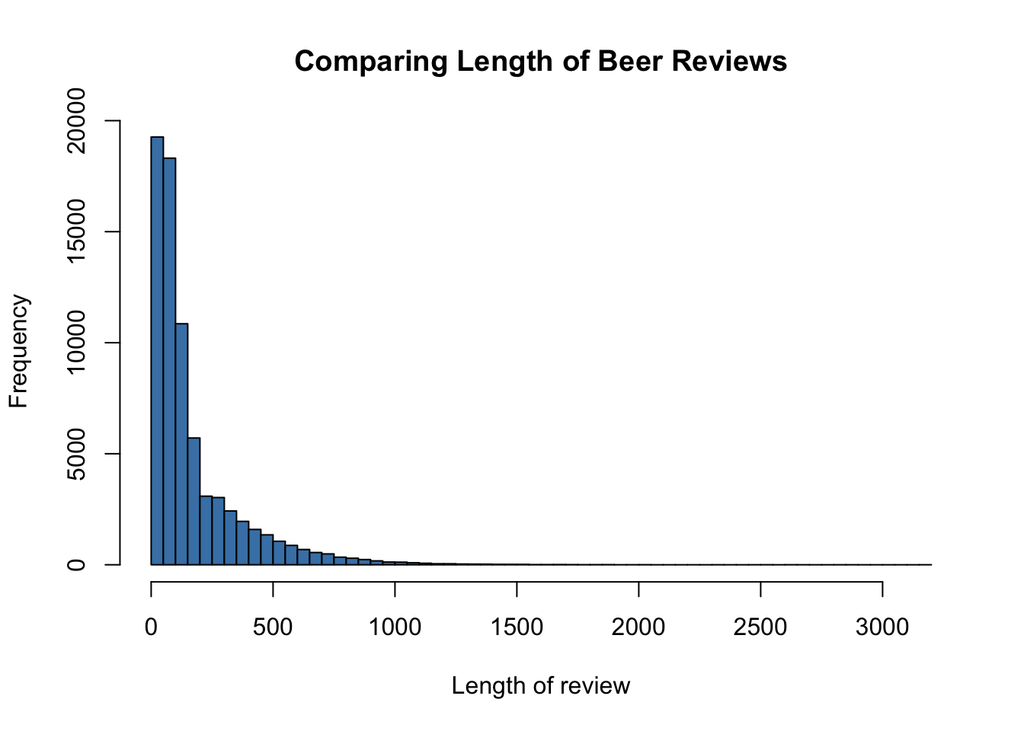

##### Code solution for method 2.

```r
#Grabbing all the styles as a vector of strings
styles <- levels(as.factor(beer.data$Style))

#creating empty vector which will eventually hold the average of each style
style_avg <- rep(0, length(styles))

for(i in 1:length(styles)){

  #Computing avg based on style
  style_avg[i] <- mean(nchar(as.character(beer.data$Review[beer.data$Style == styles[i]])))
}

#Naming each avg value their respective style name
names(style_avg) <- styles
style_avg
```

```
##           American Amber / Red Ale                American Barleywine
##                           161.4229                           181.1694
##                 American Black Ale     American Double / Imperial IPA
##                           177.0778                           179.2582
## American Double / Imperial Pilsner   American Double / Imperial Stout
##                           165.1457                           168.0977
##                       American IPA            American Pale Ale (APA)
##                           168.1500                           169.8750
##                    American Porter                American Strong Ale
##                           164.1733                           184.0529
##                  American Wild Ale                      Baltic Porter
##                           153.4740                           160.0000
##            Belgian Strong Dark Ale            Belgian Strong Pale Ale
##                           176.3759                           191.9619
##                         Doppelbock                             Dubbel
##                           180.3981                           178.8463
##                       Dunkelweizen                            Eisbock
##                           173.2887                           182.4932
##                 Flanders Oud Bruin                   Flanders Red Ale
##                           157.3851                           163.5611
##             Fruit / Vegetable Beer                             Gueuze
##                           173.2440                           143.6059
##                         Hefeweizen                     Lambic - Fruit
##                           169.3568                           154.2024
##                 Lambic - Unblended                            Old Ale
##                           131.5599                           281.0000
##                   Quadrupel (Quad)             Russian Imperial Stout
##                           183.3217                           168.9714
##             Scotch Ale / Wee Heavy                             Tripel
##                           167.3016                           177.9213
##                         Weizenbock
##                           181.0592
```

```r
#Computing total mean and sd
tot_avg <- mean(style_avg)
tot_sd <- sd(style_avg)

#Creating empty collection vectors
collection1b <- NA
collection2b <- NA
collection3b <- NA
collection4b <- NA
collection5b <- NA


#Adding each style to collection based on avg rating value and number of SDs from mean
for(i in 1:length(style_avg)){
  if(style_avg[i] < tot_avg){

    if(style_avg[i] < (tot_avg - tot_sd))
      collection1b <- c(collection1b, names(style_avg)[i])

    else
      collection2b <- c(collection2b, names(style_avg)[i])
  }

  else{
    if(style_avg[i] > tot_avg + (2 * tot_sd))
      collection5b <- c(collection5b, names(style_avg)[i])

    else if(style_avg[i] > tot_avg + tot_sd)
      collection4b <- c(collection4b, names(style_avg)[i])

    else
      collection3b <- c(collection3b, names(style_avg)[i])
  }
}

#Removing initial NA value used to create the collections
collection1b <- collection1b[-1]
collection2b <- collection2b[-1]
collection3b <- collection3b[-1]
collection4b <- collection4b[-1]
collection5b <- collection5b[-1]

#Printing collections
cat("Collection1: ",collection1b, sep = "; ")
```

```
## Collection1: ; Gueuze; Lambic - Unblended
```

```r
cat("Collection2: ",collection2b, sep = "; ")
```

[output not shown]

```r
cat("Collection3: ",collection3b, sep = "; ")
```

```
## Collection3: ; American Barleywine; American Black Ale; American Double / Imperial IPA; American Strong Ale; Belgian Strong Dark Ale; Belgian Strong Pale Ale; Doppelbock; Dubbel; Dunkelweizen; Eisbock; Fruit / Vegetable Beer; Quadrupel (Quad); Tripel; Weizenbock
```

```r
cat("Collection4: ",collection4b, sep = "; ")
```

```
## Collection4: ;
```

```r
cat("Collection5: ",collection5b, sep = "; ")
```

```
## Collection5: ; Old Ale
```

#### Interesting Discovery:

Printing out beers that are within the same collection for both methods. Its interesting to see that we collected similar beer styles based on length of the review and the rating seperately. Below is also a plot analyzing the relationship between rating and review length.

```r
#Order is based on which collection is larger as to not miss any styles when comparing
cat("Both in Collection 1: ", collection1[collection1 %in% collection1b])
```

```
## Both in Collection 1:  Lambic - Unblended
```

```r
cat("Both in Collection 2: ", collection2b[collection2b %in% collection2], sep = "; ")
```

```
## Both in Collection 2: ; American Double / Imperial Stout; American IPA; American Porter; Flanders Red Ale; Russian Imperial Stout
```

```r
cat("Both in Collection 3: ", collection3b[collection3b %in% collection3], sep = "; ")
```

```
## Both in Collection 3: ; American Barleywine; Doppelbock; Eisbock; Fruit / Vegetable Beer
```

```r
#Skipping collection4 and collection4b because the latter is empty

cat("Both in Collection 5: ", collection5[collection5b %in% collection5])
```

```
## Both in Collection 5:  Old Ale
```

Based on the plot below you can see that as the rating increases, the review length tends to increase as well.

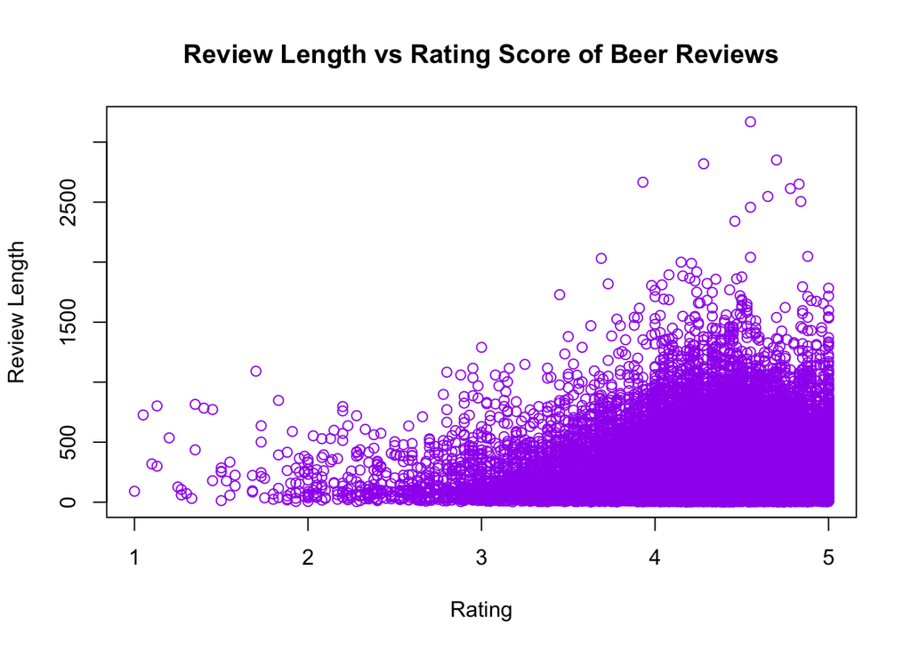

### 10)

Pliny the Younger on average has longer review entries at **191.826** characters than Pliny the Elder at **176.007** characters.

In addition, Pliny the Younger has a higher mean rating at **4.695** and a smaller standard deviation at **0.303** than Pliny the Elder at **4.599** and **0.336** respectively, statistically showing that Pliny the Younger is the better beer among the two.

```r
#Creating subsets for "Pliny The Younger" and "Pliny The Elder"
pty <- beer.data[which(beer.data$Name == "Pliny The Younger"),]
pte <- beer.data[which(beer.data$Name == "Pliny The Elder"),]

#Gathering the stats
pty.mean.review <- mean(nchar(as.character(pty$Review)))
pte.mean.review <- mean(nchar(as.character(pte$Review)))

pty.mean.rating <- mean(pty$Rating, na.rm = TRUE)
pty.sd.rating <- sd(pty$Rating, na.rm = TRUE)

pte.mean.rating <- mean(pte$Rating, na.rm = TRUE)
pte.sd.rating <- sd(pte$Rating, na.rm = TRUE)
```